# Seminario Fuentes de datos Biómédicas y Web Semántica

Relación entre la Esperanza de Vida y el consumo de Agua

Urko Alli Barrena, Paula Gregorio Losada, Victoria Garcia Lovelle

2023-12-10

[figure not shown]

# 1. Introducción

En el desarrollo de este seminario, analizaremos cómo diversos aspectos relacionados con la calidad y cantidad de agua consumida pueden influir en la esperanza de vida en las diferentes Comunidades Autónomas de España.

Exploraremos detalladamente cómo la calidad del agua, medida a través de diferentes parámetros, y la cantidad de agua, pueden ser factores determinantes para la salud y, consecuentemente, para la esperanza de vida de las Comunidades Autónomas.

# 2. Objetivos

El objetivo principal de este seminario es analizar de manera formal cómo diversos aspectos relacionados con la calidad y la cantidad de agua consumida pueden afectar en la esperanza de vida en las distintas Comunidades Autónomas de España. Se explorarán los siguientes puntos:

1. **Observar si la calidad del agua afecta directamente en la esperanza de vida**: Investigar cómo la calidad del agua puede tener repercusiones directas en la esperanza de vida de la población española por Comunidades Autónomas.
2. **Observar si la cantidad de agua consumida afecta directamente en la esperanza de vida**: Analizar de manera detallada cómo la cantidad de agua consumida puede influir en la esperanza de vida de la población española por Comunidades Autónomas.
3. **Observar si afecta el presupuesto para potabilizar el agua con la cantidad de agua consumida**: Evaluar la relación entre el presupuesto destinado a la potabilización del agua y la cantidad de agua consumida, explorando posibles implicaciones para la esperanza de vida.
4. **Impacto combinado de la calidad y cantidad de agua en la Esperanza de Vida**: Estudiar cómo la interacción entre la calidad y la cantidad de agua consumida puede tener un impacto significativo en la esperanza de vida de la población española por Comunidades Autónomas.

# 3. Carga de librerías

1. *pdftools:* Esta librería se utilizó para extraer datos de archivos PDF. En particular, se empleó para obtener información relevante sobre la calidad del agua de un informe en formato PDF.

```r
library(pdftools)
```

2. *tidyverse*: Un conjunto de paquetes que facilitan la manipulación y visualización de datos en R. Incluye librerías como tidyr y dplyr, las cuales fueron esenciales para organizar y transformar datos.

```r
library(tidyverse)
```

3. *tidyjson*: Esta librería fue útil para trabajar con datos en formato JSON. Fue esencial para analizar y extraer información de archivos JSON relacionados con la esperanza de vida y la cantidad de agua.

```r
library(tidyjson)
```

4. *rjson*: Se utilizó para cargar y procesar datos almacenados en formato JSON. Facilita la manipulación de datos estructurados y su conversión a formatos compatibles con R.

```r
library(rjson)
```

# 4. Obtención de tablas

### 4.1. Tabla de Esperanza de Vida

Para obtener la tabla de esperanza de vida se cargan los datos desde un archivo *Json*.

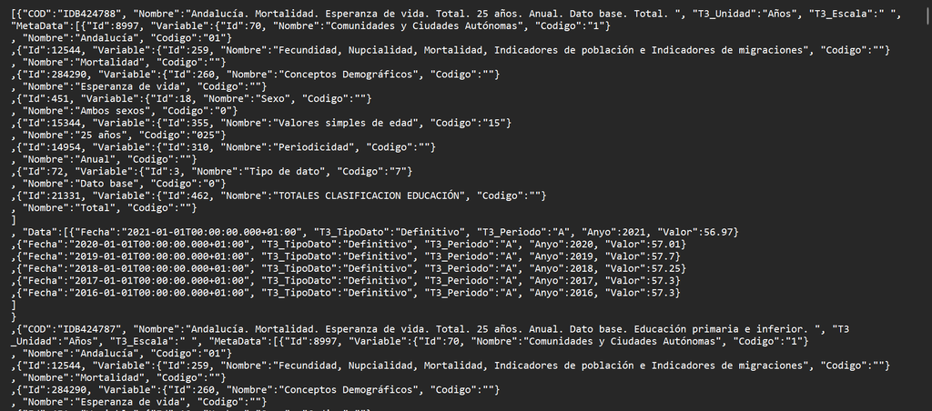

Esto es una porción de todo el archivo *Json*, del cual se tiene que seleccionar los datos deseados.

Una vez cargados los datos, se organizan en un formato de tabla y se realiza un análisis para saber qué tipos contiene la variable “EsperanzaVida”.

```r
archivoJson <- fromJSON(file = "INPUT/data/EsperanzaVida.json")

esperanzaVida <- spread_all(archivoJson)

tibble1<-esperanzaVida %>%
  gather_object %>%
  json_types %>%
  count(name, type)
```

Para obtener la tabla final se ha accedido a aquel que era de tipo *array* que contiene los valores de interés y organiza estos datos en una tabla.

```r
arrayData<-esperanzaVida %>%
  enter_object(Data) %>%
  gather_array %>%
  spread_all %>%
  select(Nombre, Anyo, Valor)
```

El atributo “Nombre” contiene una cadena de caracteres muy larga separada por puntos. Entre toda la información estan los nombres de las diferentes Comunidades Autónomas, por lo que se separa la cadena de texto y se obtienen únicamente estos nombres.

```r
partes <- strsplit(arrayData$Nombre, "\\.")

comunidadesAutonomas<-c()
for (i in partes){
  comunidadesAutonomas<-c(comunidadesAutonomas,i[1])
}

arrayData$Nombre<-comunidadesAutonomas
```

De la tabla se obtiene el año 2020 de cada Comunidad Autónoma y se obtiene como valor la media de la esperanza de vida en ese año.

Para tener todas las tablas con el mismo estilo, se han pasado los nombres de las Comunidades Autónomas a mayúsculas.

```r
tablaComunidadesAñoValor<- as_tibble(arrayData)
attr(tablaComunidadesAñoValor, "JSON") <- NULL

tablaEsperanzaDeVida <- tablaComunidadesAñoValor %>%
  filter(Anyo==2020)%>%
  group_by(Anyo, Nombre) %>%
  summarize(EsperanzaDeVida = mean(Valor, na.rm = TRUE))%>%
  rename(Año=Anyo,ComunidadAutonoma=Nombre)

tablaEsperanzaDeVidaFinal <- tablaEsperanzaDeVida %>%
  mutate(ComunidadAutonoma = toupper(ComunidadAutonoma))

colnames(tablaEsperanzaDeVidaFinal) <- c("Anio", "ComunidadAutonoma", "EsperanzaDeVida")
```

En la tabla final, se puede observar la media de la esperanza de vida de cada Comunidad Autónoma en el año 2020.

```r
tablaEsperanzaDeVidaFinal
```

```
## # A tibble: 19 × 3
## # Groups:   Anio [1]
##     Anio ComunidadAutonoma           EsperanzaDeVida
##    <dbl> <chr>                                 <dbl>
##  1  2020 ANDALUCÍA                              28.0
##  2  2020 ARAGÓN                                 28.4
##  3  2020 ASTURIAS, PRINCIPADO DE                28.1
##  4  2020 BALEARS, ILLES                         29.3
##  5  2020 CANARIAS                               29.1
##  6  2020 CANTABRIA                              28.9
##  7  2020 CASTILLA - LA MANCHA                   27.5
##  8  2020 CASTILLA Y LEÓN                        28.5
##  9  2020 CATALUÑA                               28.3
## 10  2020 CEUTA                                  26.7
## 11  2020 COMUNITAT VALENCIANA                   28.5
## 12  2020 EXTREMADURA                            27.9
## 13  2020 GALICIA                                29.3
## 14  2020 MADRID, COMUNIDAD DE                   28.0
## 15  2020 MELILLA                                26.3
## 16  2020 MURCIA, REGIÓN DE                      28.4
## 17  2020 NAVARRA, COMUNIDAD FORAL DE            29.0
## 18  2020 PAÍS VASCO                             28.8
## 19  2020 RIOJA, LA                              28.6
```

### 4.2. Tabla de la Cantidad de Agua

Para obtener la tabla de Cantidad de Agua se cargan los datos desde un archivo *Json*.

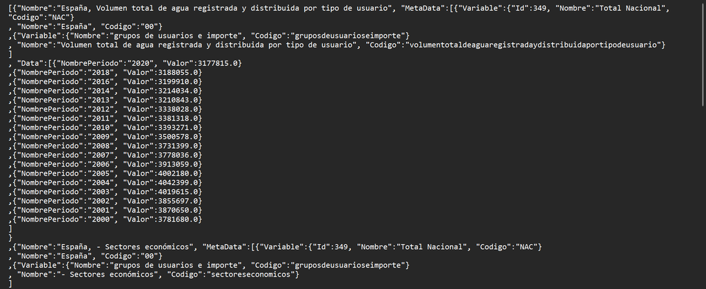

Esto es una porción de todo el archivo *Json*, del cual se tiene que seleccionar los datos deseados.

Una vez cargados los datos, se organizan en un formato de tabla y se realiza un análisis para saber qué tipos contiene la variable “cantidadAgua”.

```r
archivoJsonCantidad <- fromJSON(file = "INPUT/data/CantidadAgua.json")

cantidadAgua <- spread_all(archivoJsonCantidad)

cantidadAgua%>%
  gather_object%>%
  json_types%>%
  count(name,type)
```

```
## # A tibble: 3 × 3
##   name     type       n
##   <chr>    <fct>  <int>
## 1 Data     array    133
## 2 MetaData array    133
## 3 Nombre   string   133
```

Para poder obtener la tabla final de la cantidad de agua consumida en cada Comunidad Autónoma, se ha accedido al atributo de tipo *array* que contiene la información de interés que es Data y organiza estos datos en una tabla.

Seguidamente, como únicamente necesitamos las Comunidades Autónomas y están escritas en una larga cadena de texto, dividimos la cadena de texto y obtenemos de ella el nombre de las Comunidades Autónomas.

Esa nueva variable con las Comunidades Autónomas se añaden a la tabla final y se elimina donde ponga España.

```r
arrayDataCantidad<-cantidadAgua%>%
  enter_object(Data)%>%
  gather_array%>%
  spread_all%>%
  select(-document.id,-array.index)

cadenas <- strsplit(arrayDataCantidad$Nombre, "\\,")

comunidadesAutonomasCantidad<-c()
for (i in cadenas){
  comunidadesAutonomasCantidad<-c(comunidadesAutonomasCantidad,i[1])
}

arrayDataCantidad$Nombre<-comunidadesAutonomasCantidad

tabla <- arrayDataCantidad %>%
  filter(!(Nombre == "España")) %>%
  select(Nombre, NombrePeriodo, Valor)
```

Se filtra únicamente por el año 2020, que es el año de interés, se realiza una media de los valores obtenidos en el año 2020 de cada Comuniad Autónoma.

Para tener todas las tablas con el mismo estilo, se han pasado los nombres de las Comunidades Autónomas a mayúsculas y se han renombrado.

Por último se ha pasado a tipo entero la columna años.

```r
tablaCantidadDeAgua <- tabla %>%
  filter(NombrePeriodo  ==2020)%>%
  group_by(NombrePeriodo  , Nombre) %>%
  summarize(Cantidad = mean(Valor, na.rm = TRUE))%>%
  rename(Año=NombrePeriodo,ComunidadAutonoma=Nombre)

tablaCantidadDeAgua <- tablaCantidadDeAgua %>%
  mutate(ComunidadAutonoma = toupper(ComunidadAutonoma))

tablaCantidadDeAgua[4,2] <- c("BALEARS, ILLES")
tablaCantidadDeAgua[8,2] <- c("CASTILLA - LA MANCHA")
tablaCantidadDeAgua[14,2] <- c("MADRID, COMUNIDAD DE")
tablaCantidadDeAgua[15,2] <- c("MURCIA, REGIÓN DE")
tablaCantidadDeAgua[16,2] <- c("NAVARRA, COMUNIDAD FORAL DE")
tablaCantidadDeAgua[18,2] <- c("RIOJA, LA")

colnames(tablaCantidadDeAgua) <- c("Anio", "ComunidadAutonoma", "Cantidad")

tablaCantidadDeAguaFinal <- tablaCantidadDeAgua %>%
  mutate_at(vars(Anio), as.integer)
```

En la tabla final de la cantidad de agua, se puede observar la cantidad de agua consumida por cada Comunidad Autónoma en el año 2020.

```r
tablaCantidadDeAguaFinal
```

```
## # A tibble: 18 × 3
## # Groups:   Anio [1]
##     Anio ComunidadAutonoma           Cantidad
##    <int> <chr>                          <dbl>
##  1  2020 ANDALUCÍA                    262867
##  2  2020 ARAGÓN                        38689.
##  3  2020 ASTURIAS                      28342.
##  4  2020 BALEARS, ILLES                42033.
##  5  2020 CANARIAS                      79923.
##  6  2020 CANTABRIA                     20367.
##  7  2020 CASTILLA Y LEÓN               73272.
##  8  2020 CASTILLA - LA MANCHA          60920.
##  9  2020 CATALUÑA                     239767.
## 10  2020 CEUTA Y MELILLA                5507.
## 11  2020 COMUNITAT VALENCIANA         188854.
## 12  2020 EXTREMADURA                   28064.
## 13  2020 GALICIA                       71149
## 14  2020 MADRID, COMUNIDAD DE         216232.
## 15  2020 MURCIA, REGIÓN DE             57000.
## 16  2020 NAVARRA, COMUNIDAD FORAL DE   22551.
## 17  2020 PAÍS VASCO                    52635.
## 18  2020 RIOJA, LA                      9448.
```

### 4.3. Tabla de la Calidad del Agua

Este código extrae y procesa información relevante sobre la calidad del agua de un informe en PDF. El PDF tiene 217 páginas de las cuales la página deseada es la 17 que contiene la tabla que queremos obtener. La tabla en el PDF se muestra asi:

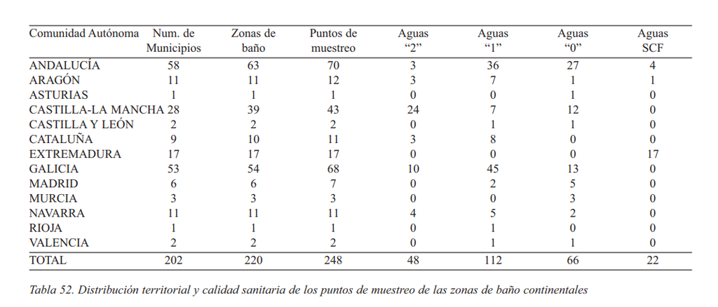

Para poder obtener esta tabla y poder utilizarla para el estudio, primero se convierte el contenido del PDF a texto y luego selecciona un rango específico de líneas en una página particular del documento (página 17), con el objetivo de obtener datos clave relacionados con la calidad del agua.

```r
ruta_pdf <- pdf_text("INPUT/data/report_Cap.3_part2._Libro_blanco_del_agua.pdf")
pagina <- ruta_pdf[17]
lineas <- strsplit(pagina, "\n")[[1]]
linea_deseada <- lineas[5:21]
```

En este código se dividen las líneas deseadas usando espacios como delimitadores. Luego, crea dos conjuntos de datos: “datos_obtenidos”, excluyendo las primeras tres dimensiones no necesarias, y “datosDeInteres”, que contiene la información esencial sobre las comunidades autónomas y los valores de la calidad del agua.

Además, se añaden manualmente filas específicas que no se extrajeron correctamente del informe.

```r
datos_divididos <- strsplit(linea_deseada, "\\s+")
datos_obtenidos <- datos_divididos[-c(1:3)]

datosDeInteres <- datos_obtenidos[-c(length(datos_obtenidos))]
datosDeInteres[[4]] <- c("CASTILLA - LA MANCHA","28","39","43","24","7","12","0")
datosDeInteres[[5]] <- c("CASTILLA Y LEÓN","2","2","2","0","1","1","0")
datosDeInteres[[9]] <- c("MADRID, COMUNIDAD DE","6","6","7","0","2","5","0")
datosDeInteres[[10]] <- c("MURCIA, REGIÓN DE","3","3","3","0","0","3","0")
datosDeInteres[[11]] <- c("NAVARRA, COMUNIDAD FORAL DE","11","11","11","4","5","2","0")
datosDeInteres[[12]] <- c("RIOJA, LA","1","1","1","0","1","0","0")
datosDeInteres[[13]] <- c("COMUNITAT VALENCIANA","2","2","2","0","1","1","0")
```

En cada iteración del bucle, se agrega la fila representada por el elemento i al data frame “tablaCalidadDeAgua” utilizando la función *rbind*( ).

Por último se renombra y se cambia a tipo numérico a aquellas columnas que sea necesario.

```r
tablaCalidadDeAgua<-data.frame()
for (i in datosDeInteres){
  tablaCalidadDeAgua<-rbind(tablaCalidadDeAgua,i)
}

colnames(tablaCalidadDeAgua) <- c("ComunidadAutonoma", "NumdeMunicipios", "ZonasdeBaño","PuntosdeMuestreo","Aguas2", "Aguas1","Aguas0", "AguasSCF")

colNumericas <- c("NumdeMunicipios", "ZonasdeBaño","PuntosdeMuestreo","Aguas2", "Aguas1","Aguas0", "AguasSCF")
tablaCalidadDeAguaFinal <- tablaCalidadDeAgua %>%
  mutate_at(vars(colNumericas), as.integer) %>%
  select(ComunidadAutonoma, Aguas2, Aguas1, Aguas0)
```

```r
tablaCalidadDeAguaFinal
```

```
##              ComunidadAutonoma Aguas2 Aguas1 Aguas0
## 1                    ANDALUCÍA      3     36     27
## 2                       ARAGÓN      3      7      1
## 3                     ASTURIAS      0      0      1
## 4         CASTILLA - LA MANCHA     24      7     12
## 5              CASTILLA Y LEÓN      0      1      1
## 6                     CATALUÑA      3      8      0
## 7                  EXTREMADURA      0      0      0
## 8                      GALICIA     10     45     13
## 9         MADRID, COMUNIDAD DE      0      2      5
## 10           MURCIA, REGIÓN DE      0      0      3
## 11 NAVARRA, COMUNIDAD FORAL DE      4      5      2
## 12                   RIOJA, LA      0      1      0
## 13        COMUNITAT VALENCIANA      0      1      1
```

En esta tabla final se pueden observar unas columnas llamadas “Aguas1”, “Aguas2” y “Aguas0”, vamos a ver a qué se refieren:

- Aguas2: Aguas aptas, de muy buena calidad.
- Aguas1: Aguas aptas, de buena calidad.
- Aguas0: Aguas no aptas, mala calidad.

Están evaluados diferentes puntos de muestreo en cada Comunidad Autónoma, de los cuales se puede observar la calidad general de cada comunidad en concreto.

### 4.4. Tabla de Presupuesto para la Potabilización del Agua

Para obtener esta tabla se ha importado un archivo CSV utilizando la función *read_csv( )* y después se renombran las columnas para tener unificados todos los nombres de las diferentes tablas.

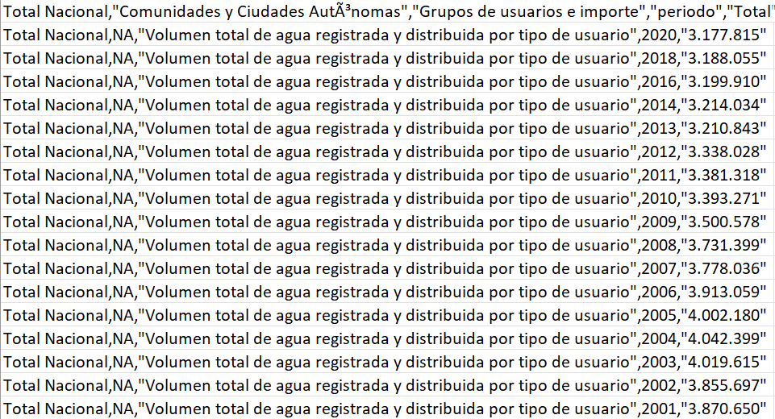

Esto es una porción de todo el archivo CSV, del cual se tiene que seleccionar los datos deseados.

Una vez cargados los datos, se renombran las columnas para poder tener unificados todos los nombres.

```r
summodificado <- read_csv("INPUT/data/summodificado.csv")
colnames(summodificado) <- c("TotalNacional", "ComunidadAutonoma", "GruposDeUsuarioEImporte","Anio", "Presupuesto")
```

Se seleccionan las filas donde la columna “GruposDeUsuarioEImporte” es igual a “Importe total de la inversión en los servicios de suministro” y la columna “Anio” es igual a “2020”.

Delante de cada nombre de la Comunidad Autónoma existe un número por lo que se elimina y se convierten los nombres de las comunidades a mayúsculas.

Se eliminan los puntos de la columna presupuesto y se pasa a tipo entero. Y por último se descarta lo que no es necesario.

```r
tablaPresupuestos <- summodificado%>%
  filter(GruposDeUsuarioEImporte=="Importe total de la inversión en los servicios de suministro" & Anio== "2020") %>%
  mutate(ComunidadAutonoma = gsub("^\\d+\\s*", "", ComunidadAutonoma)) %>%
  mutate(ComunidadAutonoma = toupper(ComunidadAutonoma)) %>%
  select (.data = ., Anio, ComunidadAutonoma:Presupuesto) %>%
  drop_na()

tablaPresupuestos$Presupuesto <- gsub("\\.", "", tablaPresupuestos$Presupuesto)
tablaPresupuestos$Presupuesto <- as.integer(tablaPresupuestos$Presupuesto)
tablaPresupuestosFinal <- tablaPresupuestos[,-3]
```

Asi obtenemos los datos de los presupuesto para la potabilización del agua en el año 2020 en las diferentes Comunidades Autónomas de España

```r
tablaPresupuestosFinal
```

```
## # A tibble: 17 × 3
##     Anio ComunidadAutonoma           Presupuesto
##    <dbl> <chr>                             <int>
##  1  2020 ANDALUCÍA                         43361
##  2  2020 ARAGÓN                              691
##  3  2020 ASTURIAS, PRINCIPADO DE             757
##  4  2020 BALEARS, ILLES                    14514
##  5  2020 CANARIAS                           4015
##  6  2020 CANTABRIA                           223
##  7  2020 CASTILLA Y LEÓN                    8083
##  8  2020 CASTILLA - LA MANCHA               2397
##  9  2020 CATALUÑA                          30222
## 10  2020 COMUNITAT VALENCIANA              39274
## 11  2020 EXTREMADURA                        2263
## 12  2020 GALICIA                            2594
## 13  2020 MADRID, COMUNIDAD DE              80532
## 14  2020 MURCIA, REGIÓN DE                  3170
## 15  2020 NAVARRA, COMUNIDAD FORAL DE        5704
## 16  2020 PAÍS VASCO                         3001
## 17  2020 RIOJA, LA                           304
```

# 5. Joins y Gráficas

En este aparatado realizamos una cantidad de cuatro joins, los cuales explicaremos a continuación.

### 5.1. Relación entre Esperanza de Vida y Cantidad

```r
EsperanzayCantidad<- tablaEsperanzaDeVidaFinal%>%
  left_join(x=., y=tablaCantidadDeAguaFinal, by=c("Anio","ComunidadAutonoma"))%>%
  group_by(ComunidadAutonoma) %>%
  drop_na()
EsperanzayCantidad
```

```
## # A tibble: 16 × 4
## # Groups:   ComunidadAutonoma [16]
##     Anio ComunidadAutonoma           EsperanzaDeVida Cantidad
##    <dbl> <chr>                                 <dbl>    <dbl>
##  1  2020 ANDALUCÍA                              28.0  262867
##  2  2020 ARAGÓN                                 28.4   38689.
##  3  2020 BALEARS, ILLES                         29.3   42033.
##  4  2020 CANARIAS                               29.1   79923.
##  5  2020 CANTABRIA                              28.9   20367.
##  6  2020 CASTILLA - LA MANCHA                   27.5   60920.
##  7  2020 CASTILLA Y LEÓN                        28.5   73272.
##  8  2020 CATALUÑA                               28.3  239767.
##  9  2020 COMUNITAT VALENCIANA                   28.5  188854.
## 10  2020 EXTREMADURA                            27.9   28064.
## 11  2020 GALICIA                                29.3   71149
## 12  2020 MADRID, COMUNIDAD DE                   28.0  216232.
## 13  2020 MURCIA, REGIÓN DE                      28.4   57000.
## 14  2020 NAVARRA, COMUNIDAD FORAL DE            29.0   22551.
## 15  2020 PAÍS VASCO                             28.8   52635.
## 16  2020 RIOJA, LA                              28.6    9448.
```

En el fragmento de código anterior, combinamos mediante un *left_join( )* las tablas de “tablaEsperanzaDeVidaFinal” y “tablaCantidadDeAguaFinal” usando sus claves comunes, las columnas “Anio” y “ComunidadAutonoma” ordenado en función de las Comunidades Autónomas.

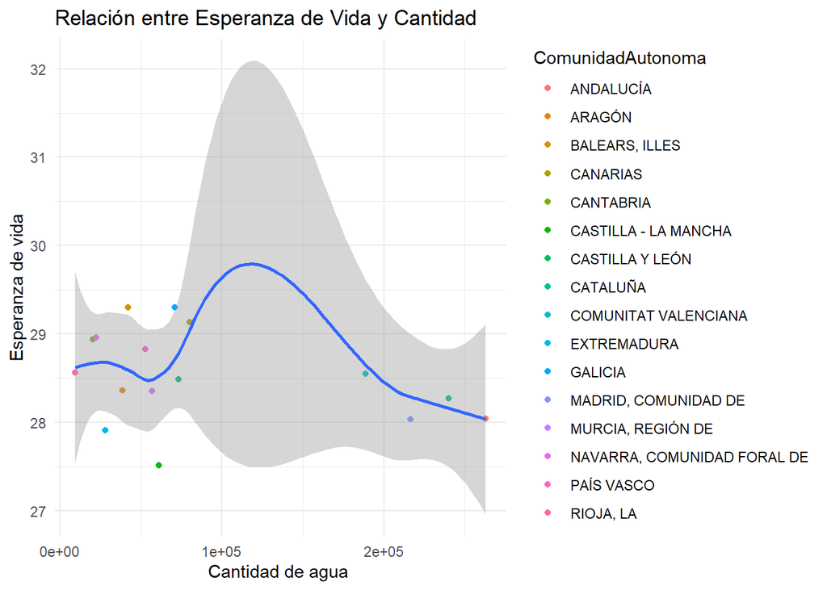

```r
grafEsperanzaCantidad <- ggplot(data=EsperanzayCantidad, aes(x=Cantidad, y=EsperanzaDeVida))+
  geom_point(aes(color=ComunidadAutonoma))+
  geom_smooth()+
  labs(title="Relación entre Esperanza de Vida y Cantidad",
       x="Cantidad de agua ",
       y="Esperanza de vida")+
  theme_minimal()
grafEsperanzaCantidad
```

Como podemos observar en esta caja de código, creamos la gráfica de la nueva tabla “EsperanzayCantidad”, creada a partir del *left_join( )* anterior. En el eje de las abscisas se representa la cantidad de agua consumida, mientras que en el eje de las ordenadas encontramos la esperanza de vida. La leyenda muestra que cada comunidad es representada en la gráfica mediante un color del gradiente y en forma circular gracias a la función “*geom_point(aes(color=ComunidadAutonoma))“*. Con la funcion *geom_smooth()* creamos la línea de tendencia, ya que tenemos un gráfico de dispersión y así podemos entender el patrón que estamos estudiando con esta gráfica.

### 5.2. Relación entre Cantidad y Presupuesto

```r
CantidadyPresupuesto<- tablaCantidadDeAguaFinal%>%
  left_join(x=., y=tablaPresupuestosFinal, by=c("Anio","ComunidadAutonoma")) %>%
  arrange(desc(Presupuesto)) %>%
  drop_na()
CantidadyPresupuesto
```

```
## # A tibble: 16 × 4
## # Groups:   Anio [1]
##     Anio ComunidadAutonoma           Cantidad Presupuesto
##    <dbl> <chr>                          <dbl>       <int>
##  1  2020 MADRID, COMUNIDAD DE         216232.       80532
##  2  2020 ANDALUCÍA                    262867        43361
##  3  2020 COMUNITAT VALENCIANA         188854.       39274
##  4  2020 CATALUÑA                     239767.       30222
##  5  2020 BALEARS, ILLES                42033.       14514
##  6  2020 CASTILLA Y LEÓN               73272.        8083
##  7  2020 NAVARRA, COMUNIDAD FORAL DE   22551.        5704
##  8  2020 CANARIAS                      79923.        4015
##  9  2020 MURCIA, REGIÓN DE             57000.        3170
## 10  2020 PAÍS VASCO                    52635.        3001
## 11  2020 GALICIA                       71149         2594
## 12  2020 CASTILLA - LA MANCHA          60920.        2397
## 13  2020 EXTREMADURA                   28064.        2263
## 14  2020 ARAGÓN                        38689.         691
## 15  2020 RIOJA, LA                      9448.         304
## 16  2020 CANTABRIA                     20367.         223
```

En el fragmento de código anterior, combinamos a través de un *left_join( )* las tablas de “tablaCantidadDeAguaFinal” y “tablaPresupuestosFinal” gracias a sus claves comunes “Anio” y “ComunidadAutonoma”, ordenadas en función de las del presupuesto de manera descendente.

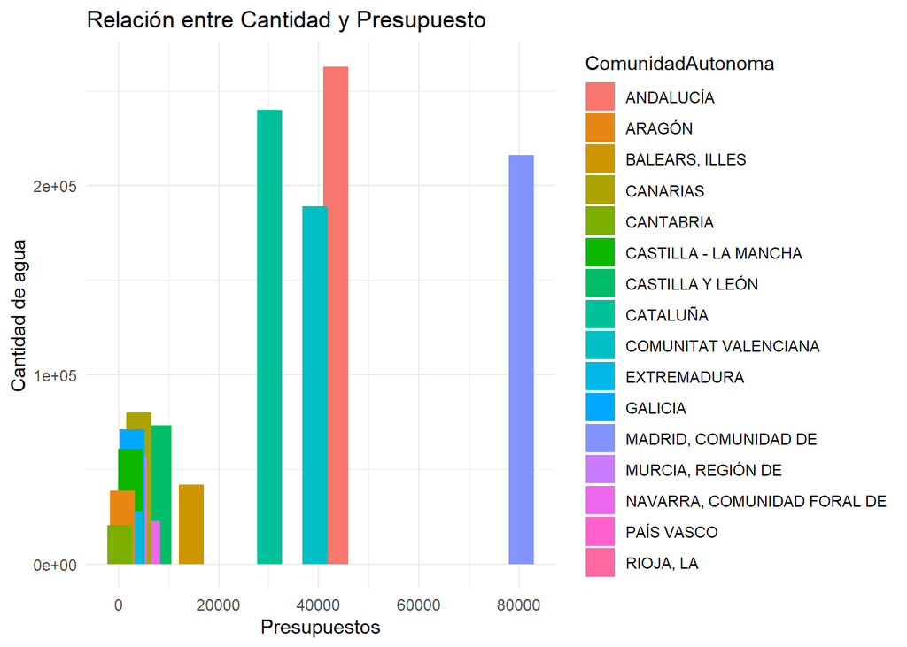

```r
grafCantidadPresupuesto <- ggplot(data=CantidadyPresupuesto, aes(x= Presupuesto, y= Cantidad, fill=ComunidadAutonoma))+
  geom_bar(stat= "identity")+
  labs(title="Relación entre Cantidad y Presupuesto",
       x="Presupuestos",
       y="Cantidad de agua")+
  geom_bar(stat= "identity", width = 5000)+
  theme_minimal()
grafCantidadPresupuesto
```

Aquí creamos la gráfica de la nueva tabla “grafCantidadPresupuesto”, creada a partir del *left_join( )* anterior. En el eje de las ordenadas encontramos la cantidad de agua consumida, y en el eje de las abscisas encontramos los presupuestos. Como podemos comprobar en la leyenda, gracias a la función *(…)fill=ComunidadAutonoma))+ geom_bar(stat= “identity”)*, cada comunidad será representada en la gráfica por un color perteneciente al gradiente y en forma de barra.

### 5.3. Relación entre Esperanza de Vida y Calidad

```r
EsperanzayCalidad<- tablaEsperanzaDeVidaFinal%>%
  left_join(x=., y=tablaCalidadDeAguaFinal, by=c("ComunidadAutonoma"))%>%
  group_by(ComunidadAutonoma) %>%
  drop_na()
EsperanzayCalidadFinal <- pivot_longer(data = EsperanzayCalidad, names_to = "CalidadAgua", values_to = "ValoresCalidadAgua", cols = c(Aguas2,Aguas1,Aguas0))

EsperanzayCalidadFinal
```

```
## # A tibble: 36 × 5
## # Groups:   ComunidadAutonoma [12]
##     Anio ComunidadAutonoma    EsperanzaDeVida CalidadAgua ValoresCalidadAgua
##    <dbl> <chr>                          <dbl> <chr>                    <int>
##  1  2020 ANDALUCÍA                       28.0 Aguas2                       3
##  2  2020 ANDALUCÍA                       28.0 Aguas1                      36
##  3  2020 ANDALUCÍA                       28.0 Aguas0                      27
##  4  2020 ARAGÓN                          28.4 Aguas2                       3
##  5  2020 ARAGÓN                          28.4 Aguas1                       7
##  6  2020 ARAGÓN                          28.4 Aguas0                       1
##  7  2020 CASTILLA - LA MANCHA            27.5 Aguas2                      24
##  8  2020 CASTILLA - LA MANCHA            27.5 Aguas1                       7
##  9  2020 CASTILLA - LA MANCHA            27.5 Aguas0                      12
## 10  2020 CASTILLA Y LEÓN                 28.5 Aguas2                       0
## # ℹ 26 more rows
```

En este código, combinamos con un *left_join( )* las tablas de “tablaEsperanzaDeVidaFinal” y “tablaCalidadDeAguaFinal” mediante su clave común, la columna “ComunidadAutonoma”, ordenado en función de la Comunidad Autónoma . De esta tabla, consideraremos las columnas “Aguas2”, “Aguas1”, “Aguas 0”, las cuales son relevantes en nuestro estudio.

Gracias a un *pivot_longer( ),* podemos crear una nueva columna “CalidadAgua”, agrupando las tres últimas columnas en distintas filas, y otra columna “ValoresCalidadAgua” con los valores correspondientes a esas variables, haciendo más fácil su posterior estudio en la gráfica.

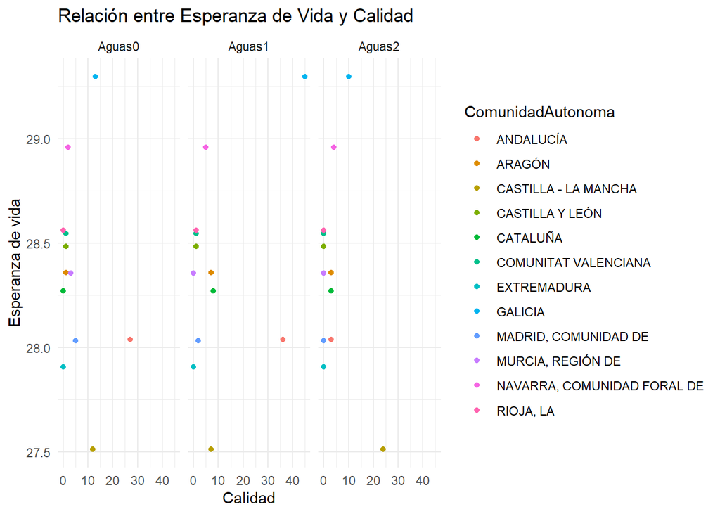

```r
grafEsperanzaCalidad <- ggplot(data = EsperanzayCalidadFinal, aes(x = ValoresCalidadAgua, y = EsperanzaDeVida)) +
  geom_point(aes(colour = ComunidadAutonoma)) +
  facet_wrap(facets = vars(CalidadAgua), nrow = 1)+
  labs(title="Relación entre Esperanza de Vida y Calidad",
       x="Calidad",
       y="Esperanza de vida")+
  theme_minimal()
grafEsperanzaCalidad
```

Para crear este gráfico a partir de la nueva tabla “CalidadyEsperanza”, utilizamos como eje de abscisas la variable “ValoresCalidadAgua”, mientras que de eje de ordenadas se encuetra la variable “EsperanzaDeVida”. Por medio de la funcion *geom_point( ),* agregamos puntos al gráfico asignando colores en función de la Comunidad Autónoma que represente. Al tener varios datos de la calidad del agua, dividimos las facetas con la ayuda de la función *facet_wrap( )* organizándolas en una sola fila.

Como se explica en el Apartado 3 de la obtención de tablas, los tres tipos de agua nos indicarán el grado de calidad de estas. Según los porcentajes obtenidos en el AnexoI, la Comunidad Autónoma que utiliza como fuente principial las aguas de tipo “Aguas 2” es Castilla-La Mancha, pero su esperaza de vida es baja. Luego, Comunidades Autónomas como Murcia y Asturias utilizan el 100% de “Aguas 0” y aun así tienen una esperanza de vida en la media en el rango de normalidad. Por último, Galicia, líder en esperanza de vida, usa en su mayoría aguas de tipo “Aguas 1”. Concluyendo así que no hay ninguna relación a primera vista sobre la calidad de agua utilizada y la esperanza de vida.

### 5.4. Relación entre Esperanza de Vida, Calidad, Presupuesto y Cantidad.

```r
tablaend<- EsperanzayCantidad %>%
  left_join(x=., y=CantidadyPresupuesto, by=c("Cantidad","ComunidadAutonoma","Anio")) %>%
  left_join(x=., y=EsperanzayCalidadFinal, by=c("ComunidadAutonoma")) %>%
  mutate(EsperanzaDeVida = coalesce(EsperanzaDeVida.x, EsperanzaDeVida.y)) %>%
  select(-EsperanzaDeVida.x, -EsperanzaDeVida.y)%>%
  mutate(Anio = coalesce(Anio.x, Anio.y))%>%
  select(-Anio.x, -Anio.y)%>%
  select(Anio, ComunidadAutonoma, everything())%>%
  drop_na()
tablaend
```

```
## # A tibble: 36 × 7
## # Groups:   ComunidadAutonoma [12]
##     Anio ComunidadAutonoma   Cantidad Presupuesto CalidadAgua ValoresCalidadAgua
##    <dbl> <chr>                  <dbl>       <int> <chr>                    <int>
##  1  2020 ANDALUCÍA            262867        43361 Aguas2                       3
##  2  2020 ANDALUCÍA            262867        43361 Aguas1                      36
##  3  2020 ANDALUCÍA            262867        43361 Aguas0                      27
##  4  2020 ARAGÓN                38689.         691 Aguas2                       3
##  5  2020 ARAGÓN                38689.         691 Aguas1                       7
##  6  2020 ARAGÓN                38689.         691 Aguas0                       1
##  7  2020 CASTILLA - LA MANC…   60920.        2397 Aguas2                      24
##  8  2020 CASTILLA - LA MANC…   60920.        2397 Aguas1                       7
##  9  2020 CASTILLA - LA MANC…   60920.        2397 Aguas0                      12
## 10  2020 CASTILLA Y LEÓN       73272.        8083 Aguas2                       0
## # ℹ 26 more rows
## # ℹ 1 more variable: EsperanzaDeVida <dbl>
```

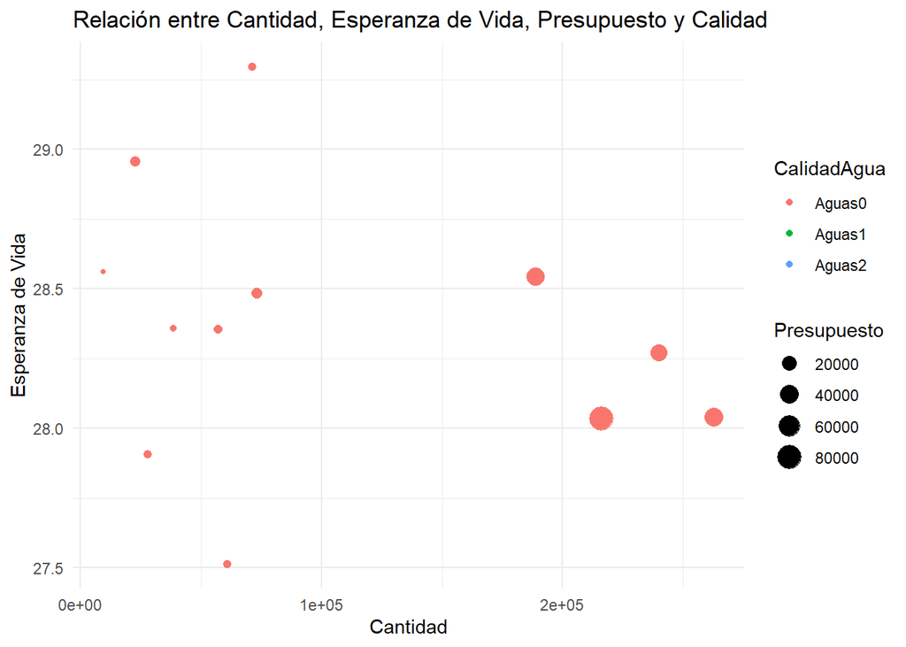

```r
grafTablaFinal <- ggplot(tablaend, aes(x = Cantidad, y = EsperanzaDeVida, size = Presupuesto, color = CalidadAgua)) +
  geom_point() +
  labs(title = "Relación entre Cantidad, Esperanza de Vida, Presupuesto y Calidad",      x = "Cantidad",
       y = "Esperanza de Vida",
       size = "Presupuesto",
       color = "CalidadAgua")+
      theme_minimal()
grafTablaFinal
```

# 6. Conclusión

A lo largo de este seminario, hemos relacionado las distintas variables con el fin de comprobar si realmente afectan o no a la esperanza de vida. Como conclusión, la esperanza de vida tiende a ser mayor si nuestro consumo de agua no excede ningun límite, permitiendo asi que aquellas Comunidades Autónomas que invierten una gran cantidad en el consumo de agua puedan reducir dicha inversión.

# Anexo I

- Orden de la tabla EsperanzayCantidad de mayor a menor en función de:

La esperanza de vida

```r
EsparanzaVidaMayorMenor <- EsperanzayCantidad[order(-EsperanzayCantidad$EsperanzaDeVida), ]
EsparanzaVidaMayorMenor
```

```
## # A tibble: 16 × 4
## # Groups:   ComunidadAutonoma [16]
##     Anio ComunidadAutonoma           EsperanzaDeVida Cantidad
##    <dbl> <chr>                                 <dbl>    <dbl>
##  1  2020 BALEARS, ILLES                         29.3   42033.
##  2  2020 GALICIA                                29.3   71149
##  3  2020 CANARIAS                               29.1   79923.
##  4  2020 NAVARRA, COMUNIDAD FORAL DE            29.0   22551.
##  5  2020 CANTABRIA                              28.9   20367.
##  6  2020 PAÍS VASCO                             28.8   52635.
##  7  2020 RIOJA, LA                              28.6    9448.
##  8  2020 COMUNITAT VALENCIANA                   28.5  188854.
##  9  2020 CASTILLA Y LEÓN                        28.5   73272.
## 10  2020 ARAGÓN                                 28.4   38689.
## 11  2020 MURCIA, REGIÓN DE                      28.4   57000.
## 12  2020 CATALUÑA                               28.3  239767.
## 13  2020 ANDALUCÍA                              28.0  262867
## 14  2020 MADRID, COMUNIDAD DE                   28.0  216232.
## 15  2020 EXTREMADURA                            27.9   28064.
## 16  2020 CASTILLA - LA MANCHA                   27.5   60920.
```

La cantidad de agua consumida

```r
CantidadAguaMayorMenor <- EsperanzayCantidad[order(-EsperanzayCantidad$Cantidad), ]
CantidadAguaMayorMenor
```

```
## # A tibble: 16 × 4
## # Groups:   ComunidadAutonoma [16]
##     Anio ComunidadAutonoma           EsperanzaDeVida Cantidad
##    <dbl> <chr>                                 <dbl>    <dbl>
##  1  2020 ANDALUCÍA                              28.0  262867
##  2  2020 CATALUÑA                               28.3  239767.
##  3  2020 MADRID, COMUNIDAD DE                   28.0  216232.
##  4  2020 COMUNITAT VALENCIANA                   28.5  188854.
##  5  2020 CANARIAS                               29.1   79923.
##  6  2020 CASTILLA Y LEÓN                        28.5   73272.
##  7  2020 GALICIA                                29.3   71149
##  8  2020 CASTILLA - LA MANCHA                   27.5   60920.
##  9  2020 MURCIA, REGIÓN DE                      28.4   57000.
## 10  2020 PAÍS VASCO                             28.8   52635.
## 11  2020 BALEARS, ILLES                         29.3   42033.
## 12  2020 ARAGÓN                                 28.4   38689.
## 13  2020 EXTREMADURA                            27.9   28064.
## 14  2020 NAVARRA, COMUNIDAD FORAL DE            29.0   22551.
## 15  2020 CANTABRIA                              28.9   20367.
## 16  2020 RIOJA, LA                              28.6    9448.
```

- Orden de la tabla Cantidad y Presupuestos en función de Cantidad:

```r
CantidadyPresupuestos<- tablaCantidadDeAguaFinal %>%
  left_join(x=., y=tablaPresupuestosFinal, by=c("Anio","ComunidadAutonoma")) %>%
  arrange(desc(Cantidad)) %>%
  drop_na()
CantidadyPresupuestos
```

```
## # A tibble: 16 × 4
## # Groups:   Anio [1]
##     Anio ComunidadAutonoma           Cantidad Presupuesto
##    <dbl> <chr>                          <dbl>       <int>
##  1  2020 ANDALUCÍA                    262867        43361
##  2  2020 CATALUÑA                     239767.       30222
##  3  2020 MADRID, COMUNIDAD DE         216232.       80532
##  4  2020 COMUNITAT VALENCIANA         188854.       39274
##  5  2020 CANARIAS                      79923.        4015
##  6  2020 CASTILLA Y LEÓN               73272.        8083
##  7  2020 GALICIA                       71149         2594
##  8  2020 CASTILLA - LA MANCHA          60920.        2397
##  9  2020 MURCIA, REGIÓN DE             57000.        3170
## 10  2020 PAÍS VASCO                    52635.        3001
## 11  2020 BALEARS, ILLES                42033.       14514
## 12  2020 ARAGÓN                        38689.         691
## 13  2020 EXTREMADURA                   28064.        2263
## 14  2020 NAVARRA, COMUNIDAD FORAL DE   22551.        5704
## 15  2020 CANTABRIA                     20367.         223
## 16  2020 RIOJA, LA                      9448.         304
```

- Porcentajes de cada tipo de agua por Comunidades Autónomas:

```r
tablaCalidadDeAguaFinalnueva <- tablaCalidadDeAgua %>%
  mutate_at(vars(colNumericas), as.integer) %>%
  select(ComunidadAutonoma, Aguas2, Aguas1, Aguas0) %>%
  mutate(total_aguas=(Aguas2+Aguas1+Aguas0)) %>%
  mutate(Agua2_porcentaje=(Aguas2/total_aguas)*100) %>%
  mutate(Agua1_porcentaje=(Aguas1/total_aguas)*100) %>%
  mutate(Agua0_porcentaje=(Aguas0/total_aguas)*100)

tablaCalidadDeAguaFinalnueva
```

```
##              ComunidadAutonoma Aguas2 Aguas1 Aguas0 total_aguas
## 1                    ANDALUCÍA      3     36     27          66
## 2                       ARAGÓN      3      7      1          11
## 3                     ASTURIAS      0      0      1           1
## 4         CASTILLA - LA MANCHA     24      7     12          43
## 5              CASTILLA Y LEÓN      0      1      1           2
## 6                     CATALUÑA      3      8      0          11
## 7                  EXTREMADURA      0      0      0           0
## 8                      GALICIA     10     45     13          68
## 9         MADRID, COMUNIDAD DE      0      2      5           7
## 10           MURCIA, REGIÓN DE      0      0      3           3
## 11 NAVARRA, COMUNIDAD FORAL DE      4      5      2          11
## 12                   RIOJA, LA      0      1      0           1
## 13        COMUNITAT VALENCIANA      0      1      1           2
##    Agua2_porcentaje Agua1_porcentaje Agua0_porcentaje
## 1          4.545455         54.54545        40.909091
## 2         27.272727         63.63636         9.090909
## 3          0.000000          0.00000       100.000000
## 4         55.813953         16.27907        27.906977
## 5          0.000000         50.00000        50.000000
## 6         27.272727         72.72727         0.000000
## 7               NaN              NaN              NaN
## 8         14.705882         66.17647        19.117647
## 9          0.000000         28.57143        71.428571
## 10         0.000000          0.00000       100.000000
## 11        36.363636         45.45455        18.181818
## 12         0.000000        100.00000         0.000000
## 13         0.000000         50.00000        50.000000
```

# Referencias

datos.gob.es. (2023, 22 noviembre). Esperanza de vida por comunidad autónoma, según sexo, edad y nivel educativo. IDB (Identificador API: 37664) - Conjunto de datos. https://datos.gob.es/es/catalogo/ea0010587-esperanza-de-vida-por-comunidad-autonoma-segun-sexo-edad-y-nivel-educativo-idb-identificador-api-37664

datos.gob.es. (2022, 6 julio). Distribución de agua registrada por comunidades y ciudades autónomas, grupos de usuarios e importe y periodo. (Identificador API: /T26/P067/P01/serie/L0/01004.Px) - Conjunto de datos. https://datos.gob.es/es/catalogo/ea0010587-distribucion-de-agua-registrada-por-comunidades-y-ciudades-autonomas-grupos-de-usuarios-e-importe-y-periodo-identificador-api-t26-p067-p01-serie-l0-01004-px

INE - Instituto Nacional de Estadística. (s. f.). Distribución de agua registrada por comunidades y ciudades autónomas, grupos de usuarios e importe y periodo. INE. https://www.ine.es/jaxi/Tabla.htm?tpx=53448&L=0

Libro blanco del agua. (s. f.-c). https://www.chsegura.es/es/cuenca/planificacion/libro-blanco-agua/